# Tarea API

Rebeca Quispe

26/4/2021

# EJERCIO 1

1. Usando la Api del banco mundial elija un indicador 3 países y un período de tiempo, descargue la base de datos y realice un gráfico en ggplot

Para la grafica utilizamos el indicador de proporcion de jovenes entre 15 a 18 años que: *ni estudian ,ni trabajan* solo estudian *estudian y trabajan* solo trabajan De los paises de Bolivia,Peru, Argentina en los años 2011 hasta el 2014

```r
library(wbstats)
library(dplyr)
```

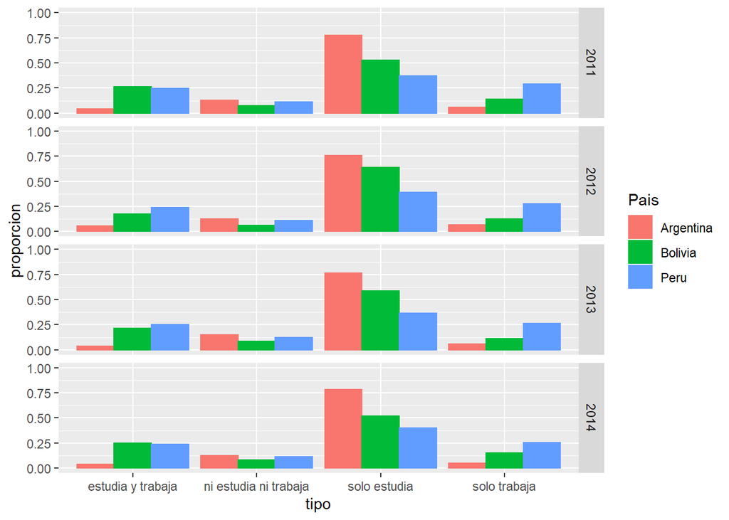

```r
library(ggplot2)
library(ggvis)
library(maps)
index_edu=wb_search(pattern ="education" )
#proporcion de jovenes que no trabajan,y ni estudian
t1=wb_data(country=c("BOL","ARG","PER"), indicator = "4.0.nini.15a18",start_date = 2011,end_date = 2014)
t1=t1%>%rename(proporcion="4.0.nini.15a18")%>%select(country,date,proporcion)%>% mutate(tipo="ni estudia ni trabaja")

#proporcion de jovenes que solo estudian
t2=wb_data(country =c("BOL","ARG","PER"), indicator = "4.0.stud.15a18",start_date = 2011,end_date = 2014)

t2=t2%>%rename(proporcion="4.0.stud.15a18")%>%select(country,date,proporcion)%>% mutate(tipo="solo estudia")
#proporcion de jovenes que estudian y trabajan
t3=wb_data(country =c("BOL","ARG","PER"), indicator = "4.0.studwork.15a18",start_date = 2011,end_date = 2014)
t3=t3%>%rename(proporcion="4.0.studwork.15a18")%>%select(country,date,proporcion)%>% mutate(tipo="estudia y trabaja")
#proporcion de jovenes que trabajan
t4=wb_data(country = c("BOL","ARG","PER"), indicator = "4.0.work.15a18",start_date = 2011,end_date = 2014)
t4=t4%>%rename(proporcion="4.0.work.15a18")%>%select(country,date,proporcion)%>% mutate(tipo="solo trabaja")
bd<-rbind(t1,t2,t3,t4)
bd=bd%>%rename(Pais="country",Año="date")
bd=bd%>%group_by(Año)

ggplot(bd,aes(tipo,proporcion,colour=Pais,fill=Pais))+geom_bar(position="dodge",stat="identity")+facet_grid(Año~.)+ylim(0,1)
```

# EJERCICIO 2

2. Elija una librería de R sobre API (no vista en clases) desarrolle un ejemplo de uso en un .rmd . Descarga, comandos, autentificación, salida tipo tabla y gráfico

## Spotifyr:

spotifyr permite extraer funciones de audio de pistas y otras funciones de la API de Spotify

### Autentificacion

Siga los siguientes pasos

- Vaya a https://developer.spotify.com/dashboard/applications.
- Inicie sesión con su cuenta de Spotify.
- Haga clic en “Crear una aplicación”.
- Elija un “Nombre de la aplicación” y una “Descripción de la aplicación” de su elección y marque las casillas de verificación.
- Después de la creación, verá su “ID de cliente” y puede hacer clic en “Mostrar secreto de cliente” para mostrar su “Secreto de cliente”.

```r
#install.packages("spotifyr")
library(devtools)
devtools::install_github("charlie86/spotifyr")
library(spotifyr)
Sys.setenv(SPOTIFY_CLIENT_ID = "9e863bdc9377459b92c18f6dfa924332")
Sys.setenv(SPOTIFY_CLIENT_SECRET ="960c16acef734711b4c9ee229fa8fd31" )
access_token <- get_spotify_access_token()
```

### Comandos

- Get Spotify Access Token:esta funcion crea un acceso a Spotify
- get_artist_audio_features:obtiene la informacion de las canciones en su totalidad o parte de la discografía de un artista *get_category_playlists:Obtiene una lista de listas de reproducción (Playlist) de Spotify etiquetadas con una categoría en particular.

```r
library(dplyr)
library(spotifyr)
library(ggplot2)
library(lubridate)
library(spotifyr)

Sys.setenv(SPOTIFY_CLIENT_ID = "9e863bdc9377459b92c18f6dfa924332")
Sys.setenv(SPOTIFY_CLIENT_SECRET ="960c16acef734711b4c9ee229fa8fd31" )
access_token <- get_spotify_access_token()


skillet <-get_artist_audio_features('skillet')
skillet%>% group_by(album_name,album_release_year) %>% select(album_name,track_name,valence,energy,danceability) %>% summarise(positividad_musical=mean(valence),nivelEnergia=mean(energy),ProbBaile=mean(danceability))
```

```
## # A tibble: 14 x 5
## # Groups:   album_name [13]
##    album_name          album_release_y~ positividad_musi~ nivelEnergia ProbBaile
##    <chr>                          <dbl>             <dbl>        <dbl>     <dbl>
##  1 Alien Youth                     2001             0.332        0.794     0.471
##  2 Awake                           2009             0.462        0.873     0.476
##  3 Collide                         2003             0.325        0.902     0.445
##  4 Collide                         2004             0.318        0.902     0.430
##  5 Comatose                        2006             0.426        0.895     0.415
##  6 Comatose Comes Ali~             2008             0.371        0.905     0.357
##  7 Hey You, I Love Yo~             1998             0.541        0.730     0.587
##  8 Invincible                      2000             0.477        0.794     0.541
##  9 Rise                            2013             0.459        0.901     0.518
## 10 Skillet                         1996             0.486        0.723     0.579
## 11 Unleashed                       2016             0.490        0.888     0.543
## 12 Victorious                      2019             0.417        0.870     0.447
## 13 Victorious: The Af~             2020             0.426        0.829     0.470
## 14 Vital Signs                     2013             0.524        0.936     0.485
```

```r
bd=skillet%>% group_by(album_name,album_release_year) %>% select(album_name,track_name,valence,energy,danceability) %>% summarise(positividad_musical=mean(valence),nivelEnergia=mean(energy),ProbBaile=mean(danceability))
```

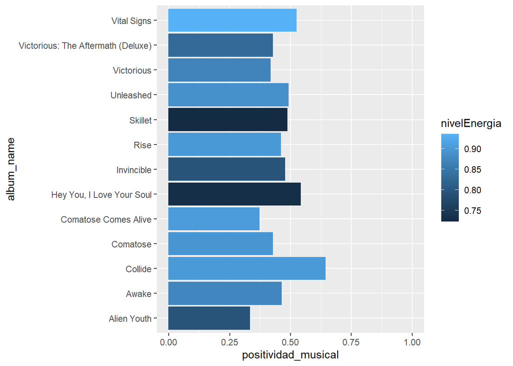

```r
#grafica representa el nivel de positividad musical promedio del album,y nivel de energia del album musical
ggplot(bd,aes(album_name,positividad_musical,colour=nivelEnergia,fill=nivelEnergia))+geom_bar(stat = "identity")+ylim(0,1)+coord_flip()
```

```r
CRock=get_category_playlists("rock")
CRock%>%select(name,tracks.total,description)
```

```
##                                     name tracks.total
## 1                          Rock Classics          145
## 2                      Rock & Roll Party           78
## 3                        80s Summer Rock           90
## 4                        90s Summer Rock          100
## 5                       00s Rock Anthems          100
## 6                       90s Rock Anthems          150
## 7                              Rock This           50
## 8                          Pure Pop Punk           50
## 9                         Grunge Forever           50
## 10                            Rock Solid           80
## 11                         Acoustic Rock           50
## 12                     Modern Chill Rock           50
## 13                      10s Rock Anthems           50
## 14      Post-Grunge Appreciation Society           70
```

[output cut: 23 more lines]